# Padrões de Infrações de Trânsito em Rodovias Federais

Pablo Gilvan Borges

Decidi trabalhar com tal conjunto de dados, visto que os mesmos apresentam dados registrados pela entidade responsável por fiscalizar e manter a ordem nas rodovias federais de todo o país. Tenho interesse, visto que trafego a quase 6 anos diariamente por rodovias federais, em identificar quais seriam os padrões de comportamento no trânsito. Me recordo de várias vezes me pegando desprevinido em um enorme engarrafamento onde sempre me questionava o que teria levado a tal situação. Sempre achei o trânsito algo tão incerto quanto o clima, temos horários propícios a transtornos e dor de cabeça, mas em dias atípicos nos vemos preso em um engarrafamento totalmente imprevisto e ocasionado por uma série de eventos que muita das vezes me deixa curioso. Sei que com tal conjunto de dados não será possível analisar tal comportamento, mas com o mesmo quero identificar padrões e comportamentos de nossa sociedade no trânsito.

#### Trabalha-se com o seguinte conjunto de dados principal:

##### 1 - Infrações de Trânsito:

Arquivo: “dez.csv”

Link: https://www.prf.gov.br/arquivos/index.php/s/RRibshM06CTBnGw

Período: Dezembro de 2018

Dicionário de dados: encontra-se no PDF “Dicionario de Variaveis_infracoes.pdf”, ou no link: https://www.prf.gov.br/portal/dados-abertos/dicionario-de-dados-infracoes/at_download/file

##### Arquivos auxiliares:

##### 1 - Listagem de Infrações por Código - CTB

Arquivo: “tbl_infracao.csv”

Link: http://repositorio.dados.gov.br/transportes-transito/transito/multas/dominio.zip

### Objetivo:

Identificar um padrão onde há um maior registro de infrações.

##### Questionamentos a serem respondidos:

-Será que um período da semana possui mais registro de infrações que outros? -Será que um período do dia, em dado período da semana, apresenta um maior registros de infrações? -Trechos de rodovias tendem a apresentar um padrão de comportamento de condução ? Ou seja, será que um certo Km de uma rodovia tende a manter um padrão de infrações em certo período do dia e da semana? -É possível associar horário/dia da semana com algum tipo de infração?

## Carregando dados

```
## [1] 727725
```

Um conjunto de dados com tamanho bem expressívo para um único mês: 727 mil registros. Agora vou carregar o conjunto auxiliar, que detalha cada código de infração registrado no dataframe ‘infracoes’ através da coluna “cod_infracao”. Assim saberemos do que se trata a infração registrada, pois no conjunto de dados da PRF eles gravam somente o código da infração.

#### Carregando o conjunto de dados que lista o descritivo de cada infração do CBT

Vale ressaltar que o conjunto de dados acima não está completamente atualizado, pois como será visto posteriormente infrações mais recentes não estão descritas no mesmo. Os dados são de outubro de 2013.

#### Inicialmente vamos listar as 10 infrações que mais aparecem no conjunto de dados.

Vamos começar agrupando as infrações por código e com isso somar quantas infrações de cada tipo foram registrados. Após isso listar as 10 infrações com mais registros.

Ok, temos uma listagem dos dados, mas, ao menos para minha pessoa, não consigo saber ao certo quais infrações competem cada código. Agora vamos associar os registros das infrações mais comuns com o descritivo de cada infração.

```
##  [1] "Transitar em velocidade superior à máxima permitida para o local, medida por instrumento ou equipamento hábil, rodovias, vias de trânsito rápido, vias arteriais e demais vias quando a velocidade for superior à máxima em até 20% (vinte por cento)                                              …
##  [2] "Transitar em velocidade superior à máxima permitida para o local, medida por instrumento ou equipamento hábil, rodovias, vias de trânsito rápido, vias arteriais e demais vias quando a velocidade for superior à máxima em mais de 20% (vinte por cento) até 50% (cinqüenta por cento)            …
##  [3] NA
##  [4] "Ultrapassar pela contramão linha de divisão de fluxos opostos, contínua amarela                                                                                                                                                                                                                    …
##  [5] "Conduzir o veículo registrado que não esteja devidamente licenciado                                                                                                                                                                                                                                …
##  [6] "Dirigir veículo sem possuir CNH ou Permissão para Dirigir                                                                                                                                                                                                                                          …
##  [7] "Deixar o condutor de usar o cinto de segurança                                                                                                                                                                                                                                                     …
##  [8] "Deixar o passageiro de usar o cinto de segurança                                                                                                                                                                                                                                                   …
##  [9] "Conduzir o veículo em mau estado de conservação, comprometendo a segurança                                                                                                                                                                                                                         …
## [10] "Transitar em velocidade superior à máxima permitida para o local, medida por instrumento ou equipamento hábil, rodovias, vias de trânsito rápido, vias arteriais e demais vias quando a velocidade for superior à máxima em mais de 50% (cinqüenta por cento)                                      …
```

Podemos notar que um registro não estava no conjunto de dados de Infrações: 72422 Buscando no Código Brasileiro de Trânsito não consegui localizar via código de multa, acessando o site do governo do Tocantins encontrei um documento que especifica o código como:

72422 - Em movimento de dia, deixar de manter acesa luz baixa nas rodovias.

Valor: $ 130.16

Consultar CTB Municipal/Rodov 250, I, b

https://central3.to.gov.br/arquivo/320049/

#### Infrações mais comuns, com descritivo

Vamos então atualizar nosso dataframe de “infracoes_mais_comuns” para que tenhamos um descritivo de quais infrações remetem a cada código. Vale ressaltar que não acho necessário atualizar o dataframe de “infracoes”, visto que repetir uma grande quantidade de informações para um conjunto de 700 mil linhas vai consumir mais memória e atrapalhar no processo de análise.

```
##  [1] "Transitar em velocidade superior à máxima permitida para o local, medida por instrumento ou equipamento hábil, rodovias, vias de trânsito rápido, vias arteriais e demais vias quando a velocidade for superior à máxima em até 20% (vinte por cento)                                              …
##  [2] "Transitar em velocidade superior à máxima permitida para o local, medida por instrumento ou equipamento hábil, rodovias, vias de trânsito rápido, vias arteriais e demais vias quando a velocidade for superior à máxima em mais de 20% (vinte por cento) até 50% (cinqüenta por cento)            …
##  [3] "Em movimento de dia, deixar de manter acesa luz\nbaixa nas rodovias."
##  [4] "Ultrapassar pela contramão linha de divisão de fluxos opostos, contínua amarela                                                                                                                                                                                                                    …
##  [5] "Conduzir o veículo registrado que não esteja devidamente licenciado                                                                                                                                                                                                                                …
##  [6] "Dirigir veículo sem possuir CNH ou Permissão para Dirigir                                                                                                                                                                                                                                          …
##  [7] "Deixar o condutor de usar o cinto de segurança                                                                                                                                                                                                                                                     …
##  [8] "Deixar o passageiro de usar o cinto de segurança                                                                                                                                                                                                                                                   …
##  [9] "Conduzir o veículo em mau estado de conservação, comprometendo a segurança                                                                                                                                                                                                                         …
## [10] "Transitar em velocidade superior à máxima permitida para o local, medida por instrumento ou equipamento hábil, rodovias, vias de trânsito rápido, vias arteriais e demais vias quando a velocidade for superior à máxima em mais de 50% (cinqüenta por cento)                                      …
```

Para podermos usar os dados de forma a categorizar os mesmos, precisamos primeiro converter os identificadores das infrações de Inteiro para Factor, assim o R não irá tratar os dados como uma variável contínua e sim categórica.

Ok, agora podemos plotar os registros e assim ter um comparativo mais visual dos dados.

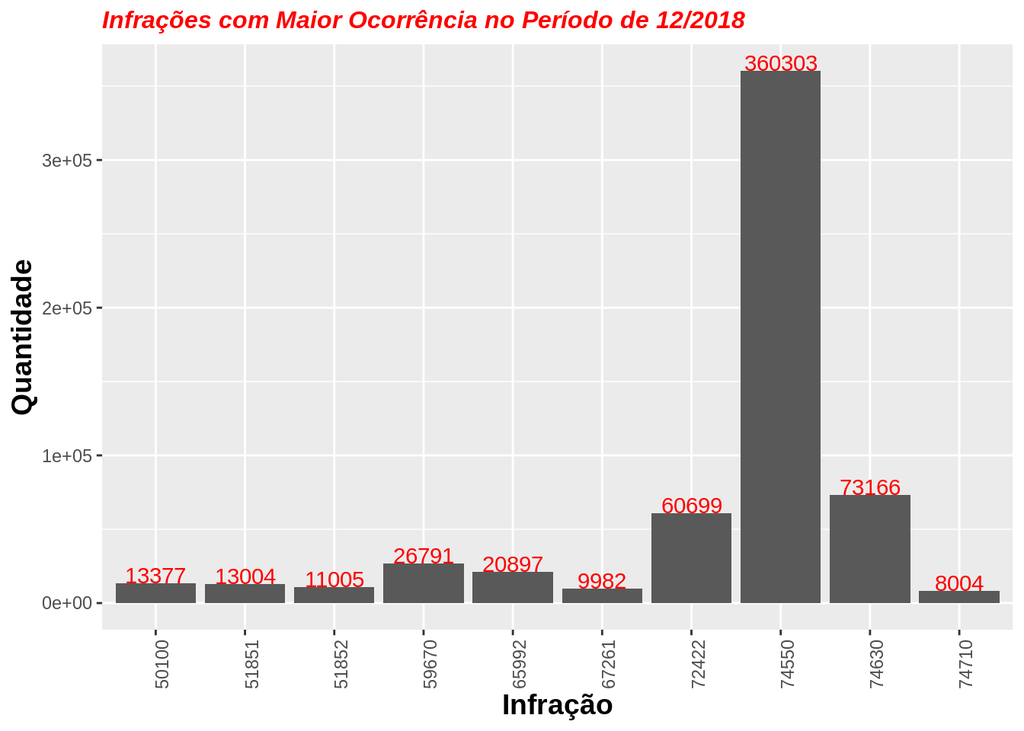

Podemos notar que 3 tipos de infrações possuem muito mais ocorrência que as demais, com destaque para a infração de código 74550. Gosto sempre de olhar os dados de forma proporcional. Vamos calcular a proporção de cada infração.

```r
num_registros <- nrow(infracoes)
infracoes_mais_comuns$proporcao <- round(infracoes_mais_comuns$registros/num_registros, digits = 2)
```

Agora podemos plotar como ficou a proporção de infrações por tipo de infração, assim temos uma ideia melhor de como estão distribuídos nossos dados.

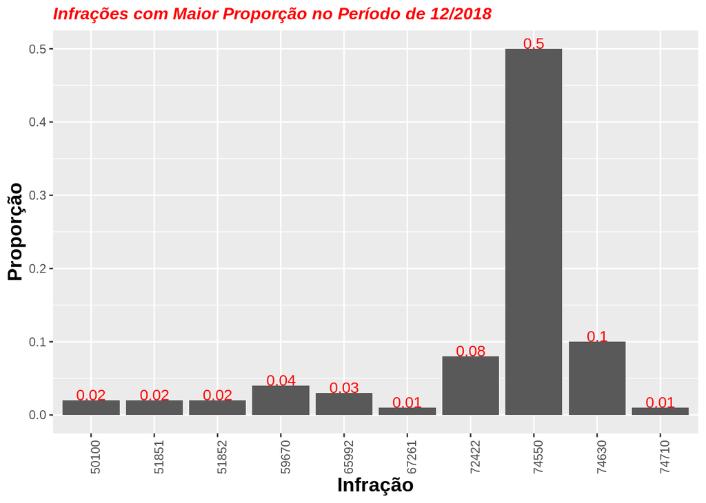

```r
infracoes_mais_comuns %>%
  ggplot(mapping = aes(x = cod_infracao, y = proporcao))+
    geom_bar(stat = "identity")+
    geom_text(aes(label=proporcao), vjust=0, color="red") +
    labs(title="Infrações com Maior Proporção no Período de 12/2018")+
    ylab("Proporção")+
    xlab("Infração")+
    theme(plot.title = element_text(color="red", size=12, face="bold.italic"),
         axis.text.x = element_text(angle = 90, hjust = 1),
         axis.title=element_text(size=14,face="bold"))
```

Com essas 3 infrações temos cerca de quase 70% de ocorrência. Vamos listar quais são.

```r
top_3 <- infracoes_mais_comuns %>%
    subset(cod_infracao == 72422 | cod_infracao == 74550 | cod_infracao == 74630)
top_3$des_infracao
```

```
## [1] "Transitar em velocidade superior à máxima permitida para o local, medida por instrumento ou equipamento hábil, rodovias, vias de trânsito rápido, vias arteriais e demais vias quando a velocidade for superior à máxima em até 20% (vinte por cento)                                               …
## [2] "Transitar em velocidade superior à máxima permitida para o local, medida por instrumento ou equipamento hábil, rodovias, vias de trânsito rápido, vias arteriais e demais vias quando a velocidade for superior à máxima em mais de 20% (vinte por cento) até 50% (cinqüenta por cento)             …
## [3] "Em movimento de dia, deixar de manter acesa luz\nbaixa nas rodovias."
```

Bacana, agora uma coisa que me deixa curioso é saber o quanto essas infrações estão gerando de valor para os cofres públicos (não quero entrar aqui no mérito de que as multas são um instrumento necessário ou não e nem se as multas ocorrem por questão de má educação no trânsito ou não). No entanto, é importante destacar que o projeto de lei mais recente(72422) já configura quase 10% das infrações no período analisado. Vamos calcular o valor que cada grupo de infrações rendeu(ou renderá) aos cofres públicos.

Primeiramente temos que converter os valores da coluna ‘valor’ de character para double, depois vamos multiplicar o valor pela quantidade de ocorrências de cada infração.

```r
infracoes_mais_comuns$valor <- as.double(infracoes_mais_comuns$valor)
infracoes_mais_comuns$arrecadacao <- round(infracoes_mais_comuns$valor * infracoes_mais_comuns$registros, digits = 2)
total <- sum(infracoes_mais_comuns$arrecadacao)
paste("R$",format(total, big.mark=".", decimal.mark = ","),sep="")
```

```
## [1] "R$73.676.163"
```

Não quero aqui entrar no mérito do valor em sí e nem se o valor de cada infração é aceitável ou não, quero somente saciar a dúvida de quanto nossa população tem que desenbolsar para pagar por seus erros ou mesmo erros de terceiros. Claro que o valor de uma vida não se compara a nada que possa ser expresso em valor monetário, mais uma vez ressalto que é somente por questões de curiosidade.

### Período do Mês com Mais Infrações

A ideia aqui é identificar os 10 dias com maior registro de infrações, tentar achar um paralelo entre finais de semans e feriados com as ocorrências de infrações. Será que o estresse do dia a dia nos faz cometer mais “burradas” ou mesmo a empolgação de finais de semanas e feriados nos levam a “relaxar” no trânsito e acabar cometendo maiores vacilos? Óbvio que somente um gráfico de barras não vais nos responder tais questionamentos, mas seria interessante visualizar tais dados e verificar alguma relação entre feriados/vésperas/finais de semanas com registros de infrações.

Antes de agrupar por data, vamos converter o valor da coluna ‘dat_infracao’ para o tipo ‘factor’, hoje a coluna está com valor ‘character’. Após isso podemos agrupar os dados. A ideia aqui é listar quais seriam as datas com maior registro de infrações.

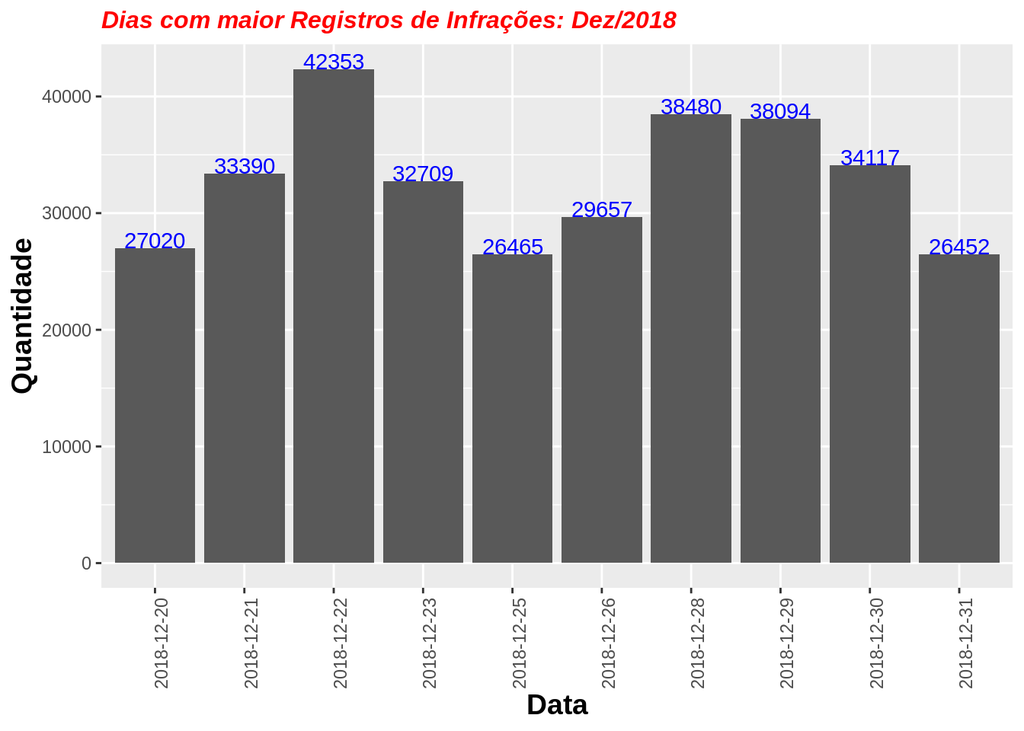

```r
infracoes$dat_infracao <- as.factor(infracoes$dat_infracao)

periodo_maior_ocorrencia <- group_by(infracoes, dat_infracao)%>%
  summarise(registros=n()) %>%
  arrange(-registros) %>%
  head(n = 10)

periodo_maior_ocorrencia %>%
  ggplot(mapping = aes(x = dat_infracao, y = registros))+
    geom_bar(stat = "identity")+
    geom_text(aes(label=registros), vjust=0, color="blue") +
    labs(title="Dias com maior Registros de Infrações: Dez/2018")+
    ylab("Quantidade")+
    xlab("Data")+
    theme(plot.title = element_text(color="red", size=12, face="bold.italic"),
         axis.text.x = element_text(angle = 90, hjust = 1),
         axis.title=element_text(size=14,face="bold"))
```

Dia 22/12 caiu em um sábado, podemos ver que os dois finais de semanas que antecediam os dois principais feriados do ano: natal e ano novo, tiveram um registro de infrações elevados em relação aos outros dias. Interessante que os dois principais dias com eventos estarem configurando os dois dias com menor registro de infrações entre os 10, com destaque para o natal que dos 10 dias foi o que teve o segundo menor valor, ficando quase com a mesma quantidade do dia 31 de Dezembro.

### Qual seria a proporção de infrações entre dias de semana e finais de semana?

Seria interessante analizar se dias da semana possuem mais infrações que os dias úteis da semana. Será que teríamos uma proporção maior de infrações para finais de semana do que para dias de semana?

Primeiramente temos que converter as datas, que hoje estão como ‘character’ para o tipo ‘date’ do R.

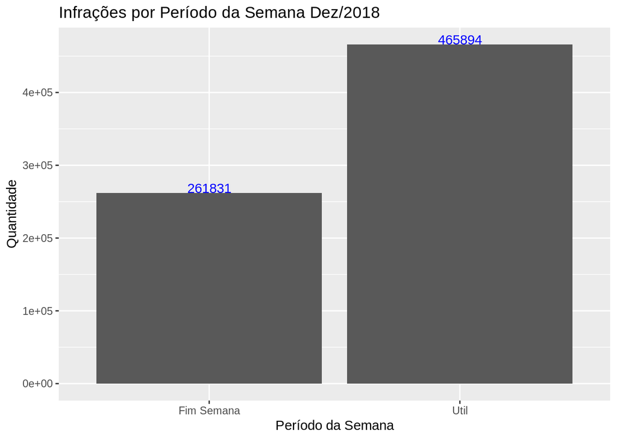

```r
infracoes$dat_infracao <- as.Date(infracoes$dat_infracao, "%Y-%m-%d")

#Agora vamos criar uma nova coluna e colocar na mesma qual dia de semana ela representa

infracoes$dia_semana <- as.numeric(format(infracoes$dat_infracao, format = "%u"))
infracoes$tipo_dia_semana <- ifelse(infracoes$dia_semana < 6, "Util", "Fim Semana")

agrupado_tipo_dia <- group_by(infracoes, tipo_dia_semana) %>%
  summarise(registros=n())

agrupado_tipo_dia %>%
  ggplot(mapping = aes(x = tipo_dia_semana, y = registros))+
    geom_bar(stat = "identity")+
    geom_text(aes(label=registros), vjust=0, color="blue") +
    labs(title="Infrações por Período da Semana Dez/2018")+
    ylab("Quantidade")+
    xlab("Período da Semana")
```

Finais de semana apresentam bem mais registros de infrações que dias de semana se verificarmos de forma proporcional, visto que um final de semana é composto por 2 dias, enquanto dias ‘úteis’ seriam 5. Mas também precisamos calcular o número de dias uteis no mês, visto que o conjunto de dados compreende um único mês. Seria interessante criar uma função para isso, assim quando quisermos analisar outros meses podemos aproveitar o código.

```r
num_weekend_days_between <- function(start, final, found = 0){
  if(start > final){
    return(found)
  }else{
    day_of_week <- as.numeric(format(start, format = "%u"))
    found <- found + ifelse(day_of_week > 5, 1, 0)
    return(num_weekend_days_between(start+1, final, found) )
  }
}
```

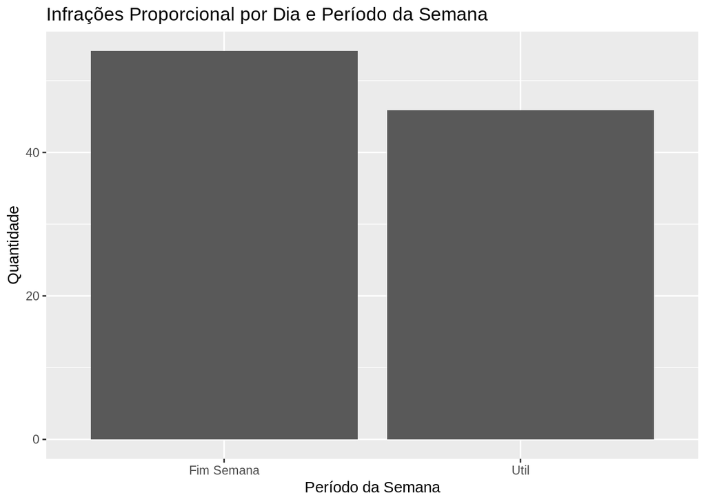

```r
weekend_days <- num_weekend_days_between(as.Date("2018-12-01"), as.Date("2018-12-31"))

agrupado_tipo_dia$proporcao <- ifelse(agrupado_tipo_dia$tipo_dia_semana == 'Util', agrupado_tipo_dia$registros/(31 - weekend_days), agrupado_tipo_dia$registros/weekend_days)
total_proporcao <- sum(agrupado_tipo_dia$proporcao)
agrupado_tipo_dia$proporcao <- (agrupado_tipo_dia$proporcao *  100)/total_proporcao

agrupado_tipo_dia %>%
  ggplot(mapping = aes(x = tipo_dia_semana, y = proporcao))+
    geom_bar(stat = "identity")+
    labs(title="Infrações Proporcional por Dia e Período da Semana")+
    ylab("Quantidade")+
    xlab("Período da Semana")
```

### Qual seria a faixa de horários com maior registro de infrações ?

Vamos focar inicialmente somente na faixa de horário, esquecendo o dia da semana. Os dados que registram a hora da infração estão no formato ‘character’, mesmo convertendo os mesmos para ‘factor’ não seria o ideal, pois os segudos nos faria terminar com muitos registros, minutos e segundos não tem tanta importância nessa análise, seria interessante agrupar por um ‘range’ de horas, algo como ‘10:00 - 11:00’, tudo que estivesse nesse interválo de tempo seria agrupado. Vamos trabalhar esses dados para melhor exibir os registros.

```r
convert_to_time_range <- function(str_value){
  if(is.null(str_value) || nchar(str_value) < 8){
      stop("\n\nFormato inválido. Horário deve estar no formato HH:mm:ss .: ", str_value)
  }

  str_value <- paste("1970-01-01", str_value)
  aux <- as_datetime(str_value)

  hour_aux = as.integer(format(as.POSIXct(aux,format="%H:%M:%S"),"%H"))

  even <- hour_aux %% 2 == 0

  start_str <- ifelse(hour_aux > 9, hour_aux, paste('0', hour_aux, sep = ''))

  response <- paste(start_str , ':00 - ', start_str, ':59', sep = '')
  return(as.factor(response))
}
```

Acima estou criando a função que, de forma mais genérica, converte uma string no padrão: ‘HH:mm:ss’ para um interválo de horários. Agora vamos criar mais uma coluna no dataset e vamos chama-la ‘horario’, usaremos esta coluna para agrupar as infrações em um dado interválo de horas e logo em seguida vamos plotar o gráfico de infrações por interválo de horários.

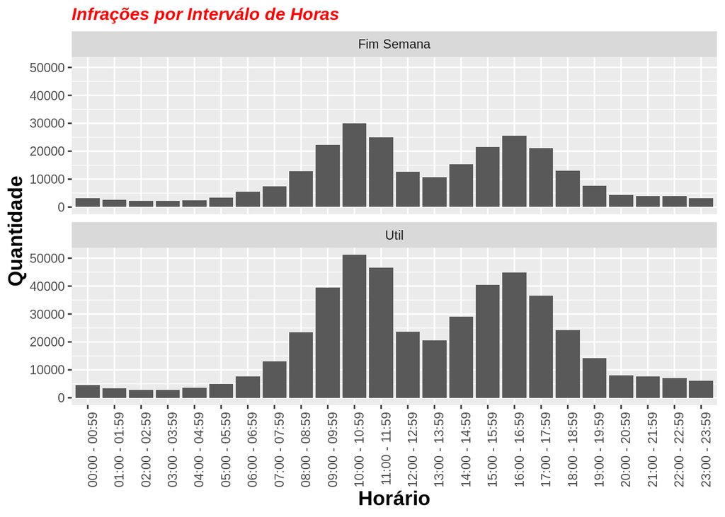

```r
infracoes$horario <- convert_to_time_range(infracoes$hora)

group_by(infracoes, tipo_dia_semana, horario) %>%
  summarise(registros=n()) %>%
  ggplot(mapping = aes(x = horario, y = registros))+
    geom_bar(stat = "identity")+
    labs(title="Infrações por Interválo de Horas")+
    ylab("Quantidade")+
    xlab("Horário")+
    theme(plot.title = element_text(color="red", size=12, face="bold.italic"),
         axis.text.x = element_text(angle = 90, hjust = 1),
         axis.title=element_text(size=14,face="bold"))+
  facet_wrap(~tipo_dia_semana, nrow = 2)
```

Interessante, nosso gráfico apresenta uma distribuição bimodal e a mesma distribuição, tanto pra dias de semana quanto para finais de semana, mas podemos ter um problema com alguns registros de infrações para vincularmos a períodos do dia. Podemos ver claramente que temos dois picos onde temos mais registros de infrações, nos períodos entre 9:00 e 13:00 e o outro entre 14:00 e 19:00. Creio que esse padrão também vai muito em relação ao trabalho de fiscalização da PRF, visto que infrações do tipo de excesso de velocidade via radar móvel não são possíveis em certos períodos do dia e como esse tipo de infração é o mais presente tende a deixar nossa análise com um viés. Seria interessante fazer a mesma análise sem os 3 primeiros registros de infrações mais presente, assim poderíamos listar infrações que não dependam somente de equipamento, mas antes vamos continuar com a análise.

#### Distribuição dos 3 tipos mais frequentes de infrações por faixa de horário

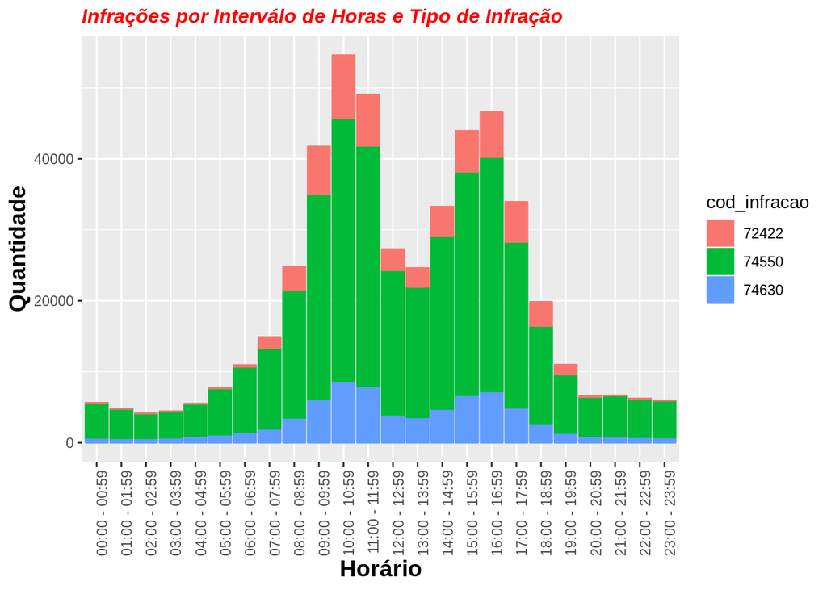

```r
mais_frequentes <- head(infracoes_mais_comuns$cod_infracao, n = 3)

infracoes %>%
  filter(cod_infracao %in% mais_frequentes) %>%
  group_by(horario, cod_infracao) %>%
    summarise(registros=n()) %>%
    ggplot(mapping = aes(x = horario, y = registros, color=cod_infracao, fill=cod_infracao))+
    geom_bar(stat = "identity")+
      labs(title="Infrações por Interválo de Horas e Tipo de Infração")+
      ylab("Quantidade")+
      xlab("Horário")+
      theme(plot.title = element_text(color="red", size=12, face="bold.italic"),
           axis.text.x = element_text(angle = 90, hjust = 1),
           axis.title=element_text(size=14,face="bold"))
```

Seria interessante verficar como seria a distribuição dos dados sem esses 3 tipos de infrações. Será que teremos uma distribuição diferente? Vou criar um novo conjunto de dados sem os 3 mais comuns e plotar a distribuição por faixa de horário.

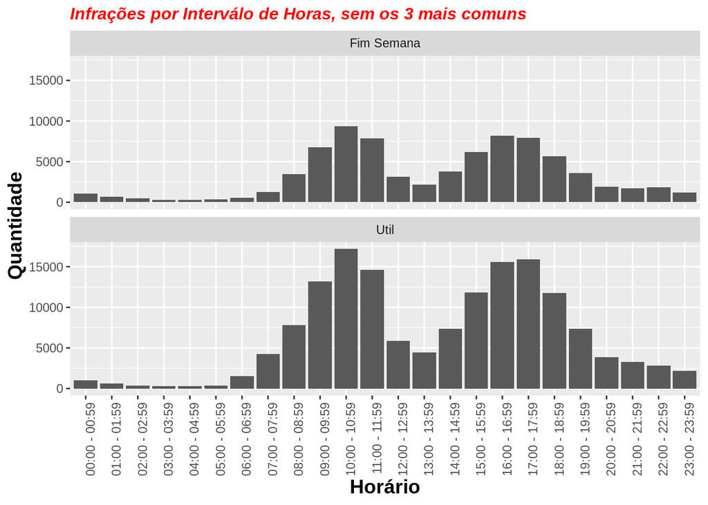

```r
infracoes %>%
  filter(!(cod_infracao %in% mais_frequentes)) %>%
  group_by(tipo_dia_semana, horario) %>%
    summarise(registros=n()) %>%
    ggplot(mapping = aes(x = horario, y = registros))+
      geom_bar(stat = "identity")+
      labs(title="Infrações por Interválo de Horas, sem os 3 mais comuns")+
      ylab("Quantidade")+
      xlab("Horário")+
      theme(plot.title = element_text(color="red", size=12, face="bold.italic"),
           axis.text.x = element_text(angle = 90, hjust = 1),
           axis.title=element_text(size=14,face="bold"))+
    facet_wrap(~tipo_dia_semana, ncol = 1)
```

Mesma distribuição dos demais, como já dito, provavelmente o período de ação da PRF deve ser mair forte neste horário, que seriam horários de pico, o que vai contra essa afirmação é termos o mesmo comportamento tanto para dias de semana quanto para finais de semana. **Update**: conversei com um policial da PRF e o mesmo me falou que grande parte dessas infrações de velocidades são oriundas de radar móvel, o que faz repensar que a baixa no fluxo de infrações no período das 12 até as 14 horas seja referente ao efetivo policial e sim referente ao fluxo de veículos.

Creio que devemos deixar um pouco de lado o horário da infração e focar em outro atributo: Km da infração.

### Trecho com maior número de infrações

Para selecionar os trechos com maior ocorrência de infrações tive também que agrupar por UF, pois visto que temos várias rodovias federais e um mesmo valor(ex: Km 2) de trecho pode corresponder a um entre vários com mesmo valor. A ideia aqui é tentar identificar se temos alguns trechos com maior ocorrência de infrações que os demais.

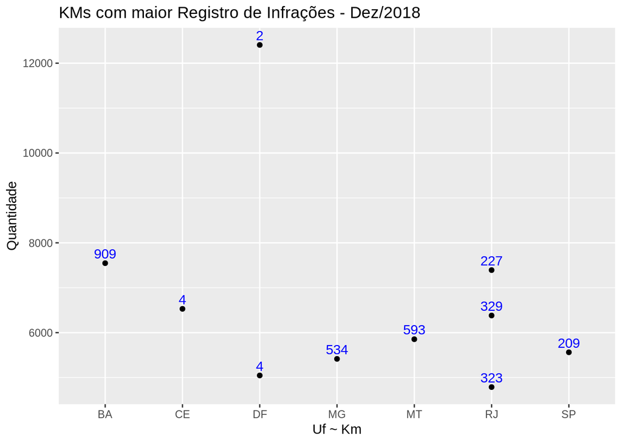

```r
trecho_maior_ocorrencia <- group_by(infracoes, num_km_infracao, uf_infracao)%>%
  summarise(registros=n()) %>%
  arrange(-registros) %>%
  head(n = 10)

trecho_maior_ocorrencia %>%
  ggplot(mapping = aes(x = uf_infracao, y = registros))+
    geom_point()+
    geom_text(aes(label=num_km_infracao), vjust= -0.5, color="blue") +
    labs(title="KMs com maior Registro de Infrações - Dez/2018")+
    ylab("Quantidade")+
    xlab("Uf ~ Km")
```

Os dados nos mostram que dos 10 trechos, com maior ocorrência de infrações, 3 pertencem ao estado do Rio de Janeiro, mas ainda assim nenhum deles com tantas ocorrências quanto o Kilômetro 2 do Distrito Federal. Creio que podemos refinar mais essa listagem e focar nos 5 Km/UF com mais registros de infrações e tentar identificar um padrão entre horário e tipo de infração.

#### Infrações por Horário nos 5 KMs com maior registro

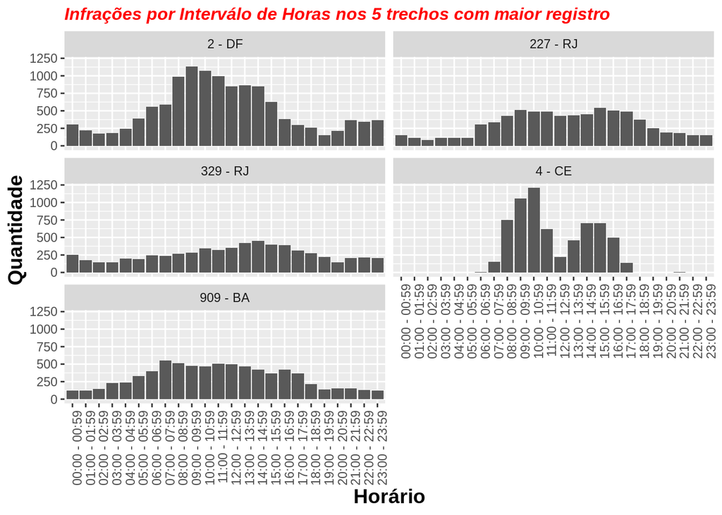

```r
infracoes$km_uf <- as.factor(paste(infracoes$num_km_infracao,'-',infracoes$uf_infracao))

trecho_maior_ocorrencia <- group_by(infracoes, km_uf)%>%
  summarise(registros=n()) %>%
  arrange(-registros) %>%
  head(n = 5)

kms_mais_frequentes <- head(trecho_maior_ocorrencia$km_uf)

trechos_mais_infracoes <- infracoes %>%
  filter(km_uf %in% kms_mais_frequentes)

trechos_mais_infracoes %>%
  group_by(km_uf, horario) %>%
    summarise(registros=n()) %>%
    ggplot(mapping = aes(x = horario, y = registros))+
      geom_bar(stat = "identity")+
      labs(title="Infrações por Interválo de Horas nos 5 trechos com maior registro")+
      ylab("Quantidade")+
      xlab("Horário")+
      theme(plot.title = element_text(color="red", size=12, face="bold.italic"),
           axis.text.x = element_text(angle = 90, hjust = 1),
           axis.title=element_text(size=14,face="bold"))+
    facet_wrap(~km_uf, ncol = 2)
```

Interessante, podemos notar uma distribuição bimodal no KM 4 do CE, de leve o mesmo padrão no KM 227 do RJ e no KM 2 do DF. O único mesmo que segue o padrão da distribuição do conjunto de dados é o KM 4 do CE, podemos notar uma distribuição bem diferente no KM 329 do RJ e uma, não tão diferente, no KM 909 da BA. Vamos trocar o foco, verificar como se dá essa distribuição por tipo de dia da semana.

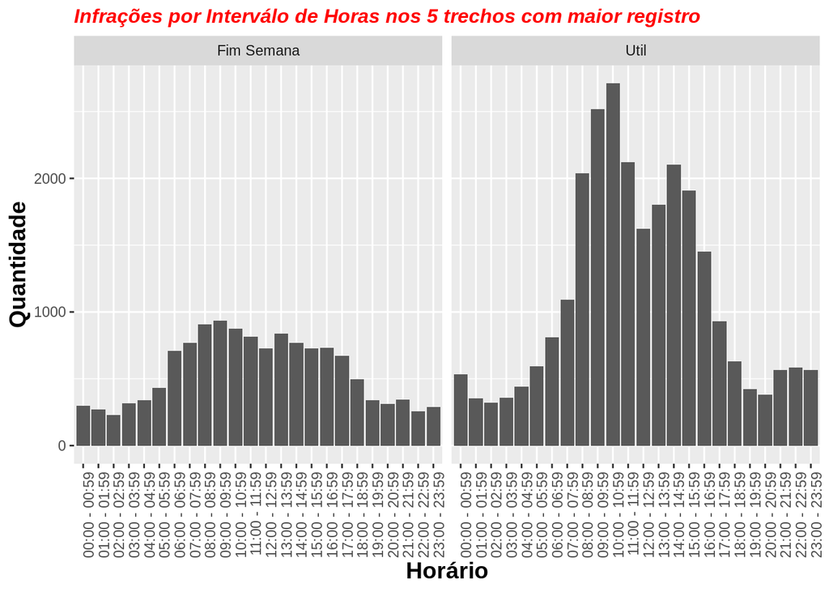

```r
trechos_mais_infracoes %>%
  group_by(tipo_dia_semana, horario) %>%
    summarise(registros=n()) %>%
    ggplot(mapping = aes(x = horario, y = registros))+
      geom_bar(stat = "identity")+
      labs(title="Infrações por Interválo de Horas nos 5 trechos com maior registro")+
      ylab("Quantidade")+
      xlab("Horário")+
      theme(plot.title = element_text(color="red", size=12, face="bold.italic"),
           axis.text.x = element_text(angle = 90, hjust = 1),
           axis.title=element_text(size=14,face="bold"))+
    facet_wrap(~tipo_dia_semana, ncol = 2)
```

Interessante, aqui já temos novamente a distribuição bimodal de forma mais acentuada nos dias de semana e podemos notar a mesma se formando em finais de semana. O interessante é notar que nos dias de semana temos um registro elevado de infrações no período daas 21:00 até a 1:00, note esse comportamento no KM 2 do DF.

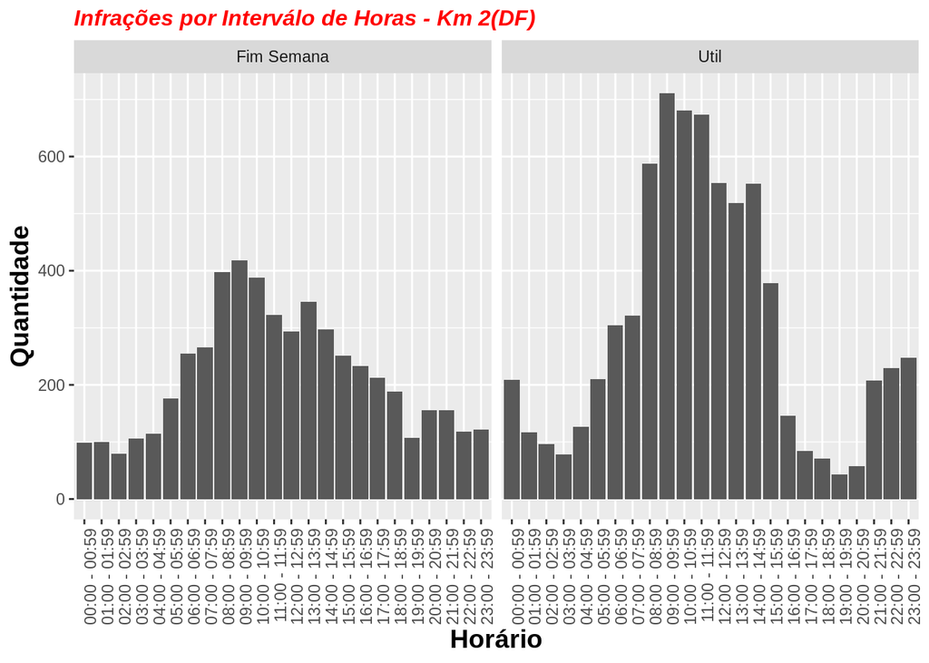

```r
trechos_mais_infracoes %>%
  filter(km_uf == '2 - DF') %>%
  group_by(tipo_dia_semana, km_uf, horario) %>%
    summarise(registros=n()) %>%
    ggplot(mapping = aes(x = horario, y = registros))+
      geom_bar(stat = "identity")+
      labs(title="Infrações por Interválo de Horas - Km 2(DF)")+
      ylab("Quantidade")+
      xlab("Horário")+
      theme(plot.title = element_text(color="red", size=12, face="bold.italic"),
           axis.text.x = element_text(angle = 90, hjust = 1),
           axis.title=element_text(size=14,face="bold"))+
    facet_wrap(~tipo_dia_semana, ncol = 2)
```

Podemos notar que a distribuição dos dados para dias de semana no KM 2(DF) é um pouco semelhante a distribuição do conjunto com os demais trechos, principalmente o que remete ao período das 21:00 até as 01:00, mas nessa distribuição podemos notar um formato de uma distribuição simetrica na parte central, sabendo que isso seria um range de horários e a forma que estamos exibindo os mesmos poderia exibir uma distribuição bimodal para o mesmo, pois se movermos o gráfico um pouco para a esquerda ou mesmo direita poderamos notar as duas, vamos dizer quase, se formando. Já temos um cenário bem diferente para finais de semana, onde temos uma distribuição mais centralizada nos horários entre 05:00 e 17:00.

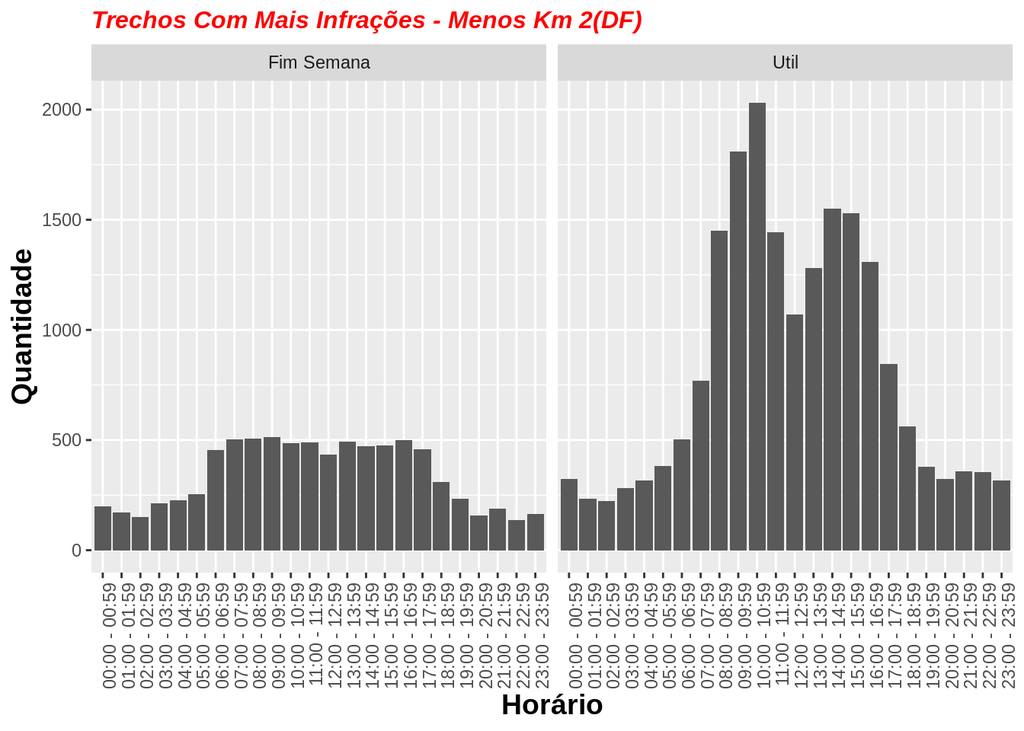

```r
trechos_mais_infracoes %>%
  filter(km_uf != '2 - DF') %>%
  group_by(tipo_dia_semana, km_uf, horario) %>%
    summarise(registros=n()) %>%
    ggplot(mapping = aes(x = horario, y = registros))+
      geom_bar(stat = "identity")+
      labs(title="Trechos Com Mais Infrações - Menos Km 2(DF)")+
      ylab("Quantidade")+
      xlab("Horário")+
      theme(plot.title = element_text(color="red", size=12, face="bold.italic"),
           axis.text.x = element_text(angle = 90, hjust = 1),
           axis.title=element_text(size=14,face="bold"))+
    facet_wrap(~tipo_dia_semana, ncol = 2)
```

Já para esse conjunto de dados temos uma distruibuição bimodal para dias de semana e para finais de semana uma distribuição quase assímétrica, se “forçarmos” um pouco a visão podemos quase perceber uma distribuição bimodal se formando.

Vamos listar quais são os 5 tipos de infrações mais decorrentes deste conjunto de dados.

```r
infracoes_mais_comuns <- group_by(trechos_mais_infracoes, cod_infracao)%>%
  summarise(registros=n()) %>%
  arrange(-registros) %>%
  head(n = 5)

#Como alterei o tipo da coluna cod_infracao do dataset principal, vou ter que alterar o tipo também para o conjunto de dados tbl_infracao
tbl_infracao$cod_infracao <- as.factor(tbl_infracao$cod_infracao)

infracoes_mais_comuns <- infracoes_mais_comuns %>%
  left_join(tbl_infracao, by = "cod_infracao")
# Como o conjunto de dados possui valores incompletos para infracoes de codigo 72422 já carrego os descritivos abaixo.
infracoes_mais_comuns$des_infracao[infracoes_mais_comuns$cod_infracao == 72422] <- "Em movimento de dia, deixar de manter acesa luz baixa nas rodovias."
infracoes_mais_comuns$valor[infracoes_mais_comuns$cod_infracao == 72422] <- "130.16"
infracoes_mais_comuns$enquadramento[infracoes_mais_comuns$cod_infracao == 72422] <- "250 I, b"

infracoes_mais_comuns$des_infracao
```

```
## [1] "Transitar em velocidade superior à máxima permitida para o local, medida por instrumento ou equipamento hábil, rodovias, vias de trânsito rápido, vias arteriais e demais vias quando a velocidade for superior à máxima em até 20% (vinte por cento)                                               …
## [2] "Transitar em velocidade superior à máxima permitida para o local, medida por instrumento ou equipamento hábil, rodovias, vias de trânsito rápido, vias arteriais e demais vias quando a velocidade for superior à máxima em mais de 20% (vinte por cento) até 50% (cinqüenta por cento)             …
## [3] "Transitar em velocidade superior à máxima permitida para o local, medida por instrumento ou equipamento hábil, rodovias, vias de trânsito rápido, vias arteriais e demais vias quando a velocidade for superior à máxima em mais de 50% (cinqüenta por cento)                                       …
## [4] "Em movimento de dia, deixar de manter acesa luz baixa nas rodovias."
## [5] "Conduzir o veículo registrado que não esteja devidamente licenciado                                                                                                                                                                                                                                 …
```

Nesse conjunto de dados temos um diferencial, os 3 primeiros tipos de infrações mais decorrentes são infrações onde temos excesso de velocidade. Seria interessante usar este conjunto de dados e listar os horários e a quantidade de infrações para cada um dos 3 tipos de infração de excesso de velocidade. Será que os índices de excesso a 50% da velocidade permitida se concentra mais em horários fora dos chamados “horários de pico” e em finais de semana?

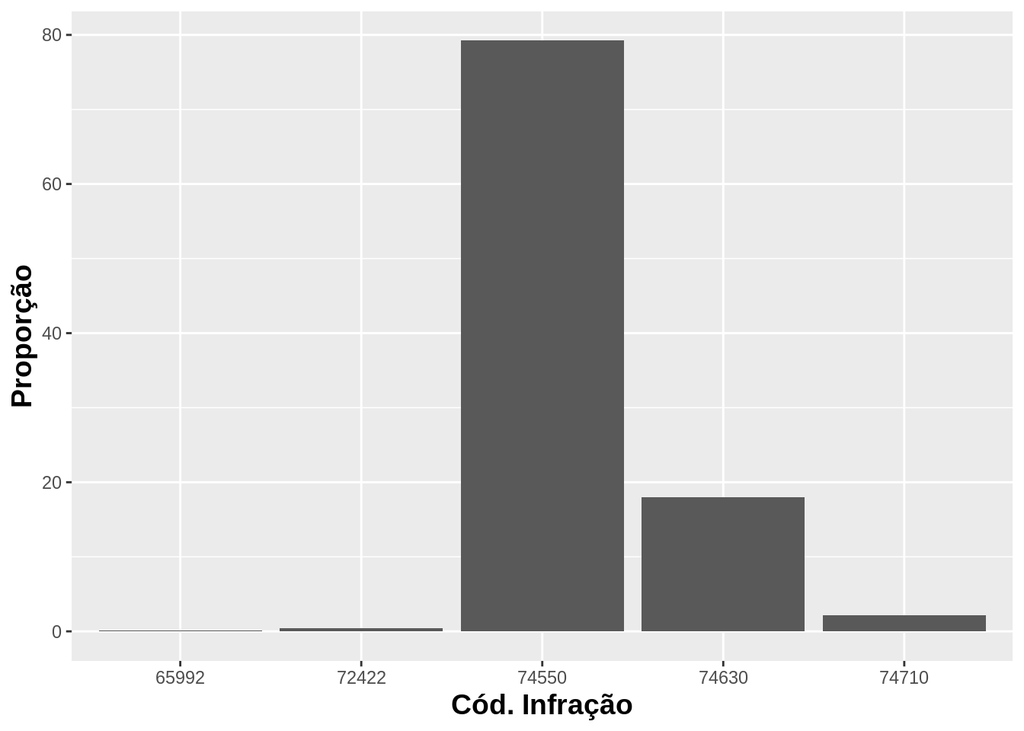

```r
cod_infracoes_top_5 <- infracoes_mais_comuns$cod_infracao

trechos_grupo_tipo_infracao <- trechos_mais_infracoes %>%
  filter(cod_infracao %in% cod_infracoes_top_5) %>%
  group_by(tipo_dia_semana, cod_infracao) %>%
    summarise(registros=n())

trechos_grupo_tipo_infracao$proporcao <- (trechos_grupo_tipo_infracao$registros*100)/sum(trechos_grupo_tipo_infracao$registros)

trechos_grupo_tipo_infracao %>%
    ggplot(mapping = aes(x = cod_infracao, y = proporcao))+
      geom_bar(stat = "identity")+
      ylab("Proporção")+
      xlab("Cód. Infração")+
      theme(plot.title = element_text(color="red", size=12, face="bold.italic"),
           axis.title=element_text(size=14,face="bold"))
```

Percebemos que quase 80% das infrações foram de código 74550. Vamos exibir a quantidade para dias de semana e finais de semana.

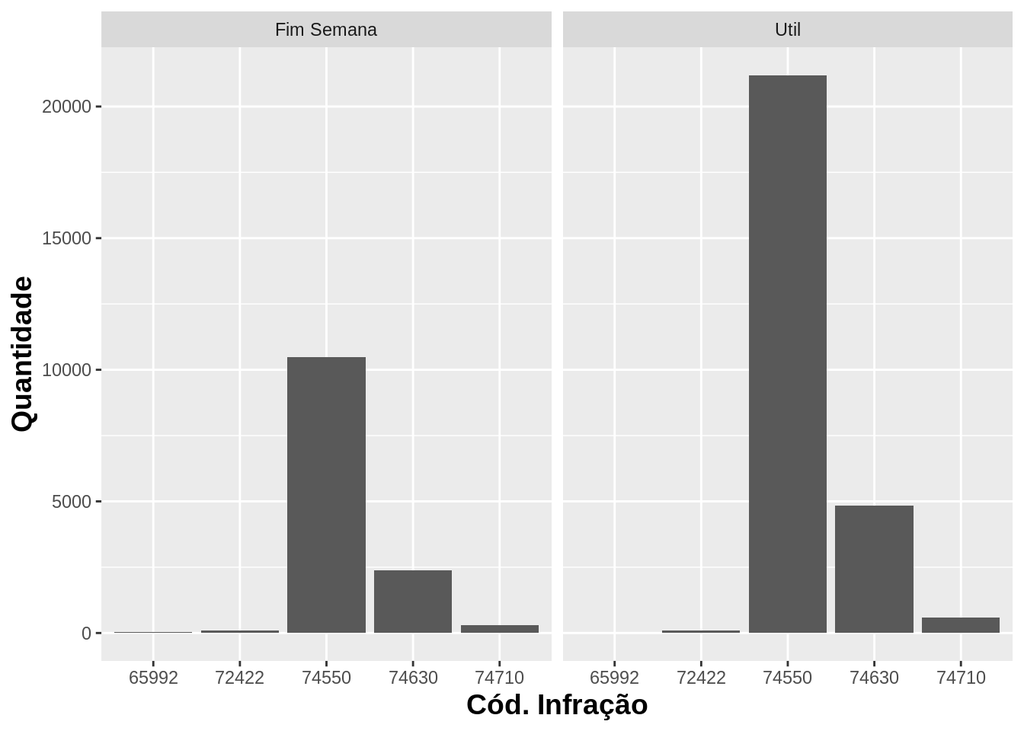

```r
trechos_grupo_tipo_infracao %>%
    ggplot(mapping = aes(x = cod_infracao, y = registros))+
      geom_bar(stat = "identity")+
      ylab("Quantidade")+
      xlab("Cód. Infração")+
      theme(plot.title = element_text(color="red", size=12, face="bold.italic"),
           axis.title=element_text(size=14,face="bold"))+
  facet_wrap(~tipo_dia_semana)
```

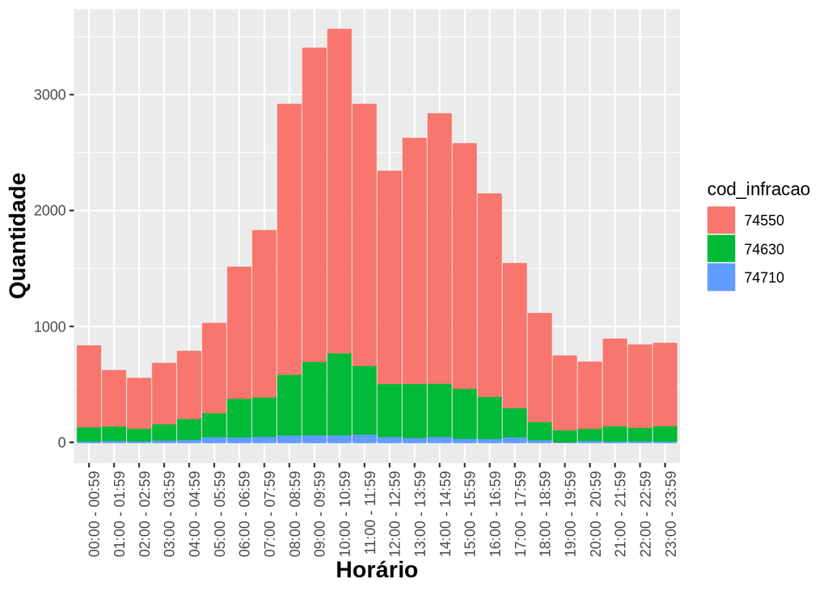

```r
trechos_mais_infracoes %>%
  filter(cod_infracao %in% c('74550', '74630', '74710')) %>%
  group_by(horario, cod_infracao) %>%
    summarise(registros=n()) %>%
    ggplot(mapping = aes(x = horario, y = registros, color=cod_infracao, fill=cod_infracao))+
    geom_bar(stat = "identity")+
      ylab("Quantidade")+
      xlab("Horário")+
      theme(plot.title = element_text(color="red", size=12, face="bold.italic"),
           axis.text.x = element_text(angle = 90, hjust = 1),
           axis.title=element_text(size=14,face="bold"))
```

Podemos notar o mesmo padrão para o conjunto de dados geral, onde não tínhamos somente alguns trechos. Muito interessante o fato de que a distribuição é quase a mesma. Poderíamos até divagar e ironizar o fato de que se não fosse a pausa do horário de almoço teríamos uma distribuição simétrica, pois parece que quanto mais pŕoximo dos horários de interválo de jornada de trabalho temos um acréscimo na quantidade de infrações e o caminho inverso quanto mais próximo do término do interválo.

### Estados com mais registros de infrações - Dezembro/2018

Creio que para localizar os trechos com mais infrações não basta somente o kilômetro do ocorrido, analisar os estados com maior registro de infrações nos facilitará filtrar os registros e assim plotar um gráfico por km e UF. Vamos então começar listando os estados com maior registro de infrações.

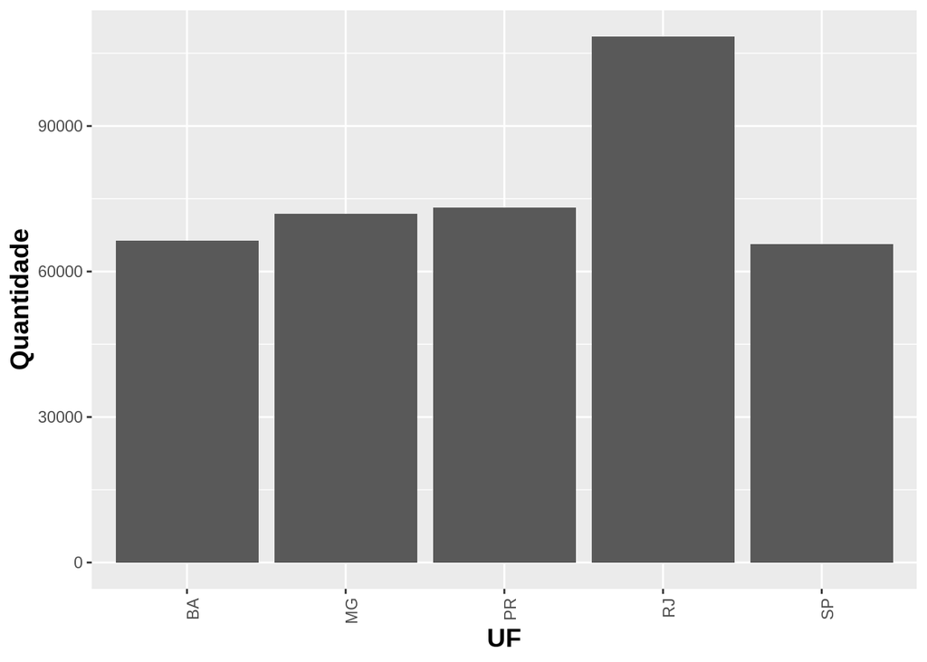

```r
ufs_maior_ocorrencia <- group_by(infracoes, uf_infracao)%>%
  summarise(registros=n()) %>%
  arrange(-registros) %>%
  head(n = 5)

ufs_maior_ocorrencia %>%
    ggplot(mapping = aes(x = uf_infracao, y = registros))+
    geom_bar(stat = "identity")+
      ylab("Quantidade")+
      xlab("UF")+
      theme(plot.title = element_text(color="red", size=12, face="bold.italic"),
           axis.text.x = element_text(angle = 90, hjust = 1),
           axis.title=element_text(size=14,face="bold"))
```

Agora podemos visualizar um gráfico de forma a ver cada KM de cada Estado e a quantidade na segmentação dos kms. Primeiramente temos que converter a coluna ‘num_km_infracao’, que está como tipo ‘factor’, para tipo ‘number’.

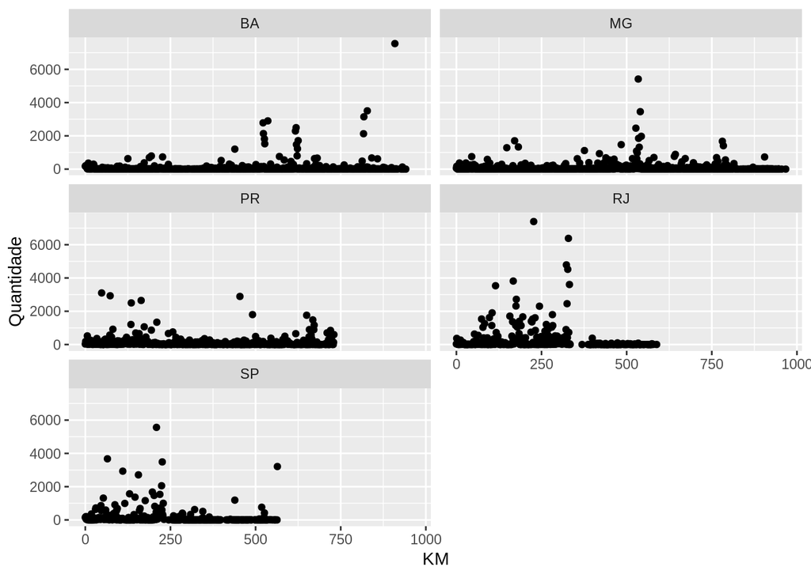

```r
infracoes$num_km_infracao <- as.numeric(infracoes$num_km_infracao)

ufs_maior_ocorrencia <- filter(infracoes, uf_infracao %in% ufs_maior_ocorrencia$uf_infracao)

ufs_maior_ocorrencia %>%
  group_by(uf_infracao, num_km_infracao)%>%
  summarise(registros=n()) %>%
    ggplot(mapping = aes(x = num_km_infracao, y = registros))+
    geom_point()+
      ylab("Quantidade")+
      xlab("KM")+
  facet_wrap(~uf_infracao, ncol = 2)
```

Um caso interessante que de todos os 5 estados o Rio de Janeiro é o menor, mas apresenta uma frequência bem alta de infrações e em kilômetros bem próximos, claro que podemos olhar pelo lado de que o estado é menor, logo possui menos kilômetros de rodovias, mas se olharmos para São Paulo, por exemplo, ele tem uma distribuição bem mais ampla e com uma frequência menor para cada trecho. Vou olhar somente para o estado do Rio de Janeiro.

##### Distribuição de Infrações por KMs - RJ

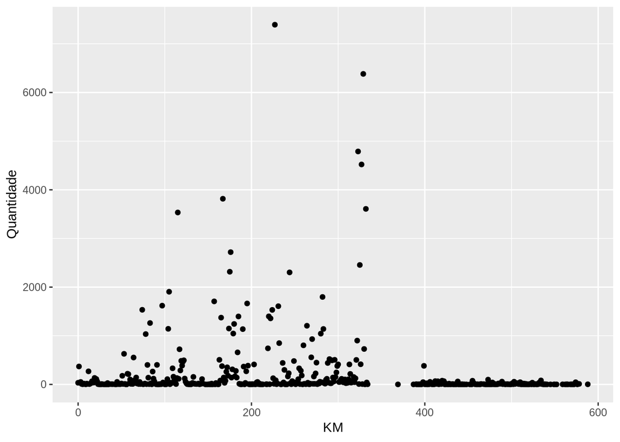

```r
ufs_maior_ocorrencia %>%
  filter(uf_infracao == 'RJ') %>%
  group_by(uf_infracao, num_km_infracao)%>%
  summarise(registros=n()) %>%
    ggplot(mapping = aes(x = num_km_infracao, y = registros))+
    geom_point()+
      ylab("Quantidade")+
      xlab("KM")
```

Kms entre 150 e 350 apresentam um alto registro de infrações, vamos listar e verificar quantos trechos temos dentro dessa faixa de valores.

```r
kms_rj <- ufs_maior_ocorrencia %>%
  filter(uf_infracao == 'RJ' & num_km_infracao >= 150 & num_km_infracao <= 350) %>%
  group_by(uf_infracao, num_km_infracao)


paste("Total de", format(length(unique(kms_rj$num_km_infracao))), " trechos encontrados.")
```

```
## [1] "Total de 178  trechos encontrados."
```

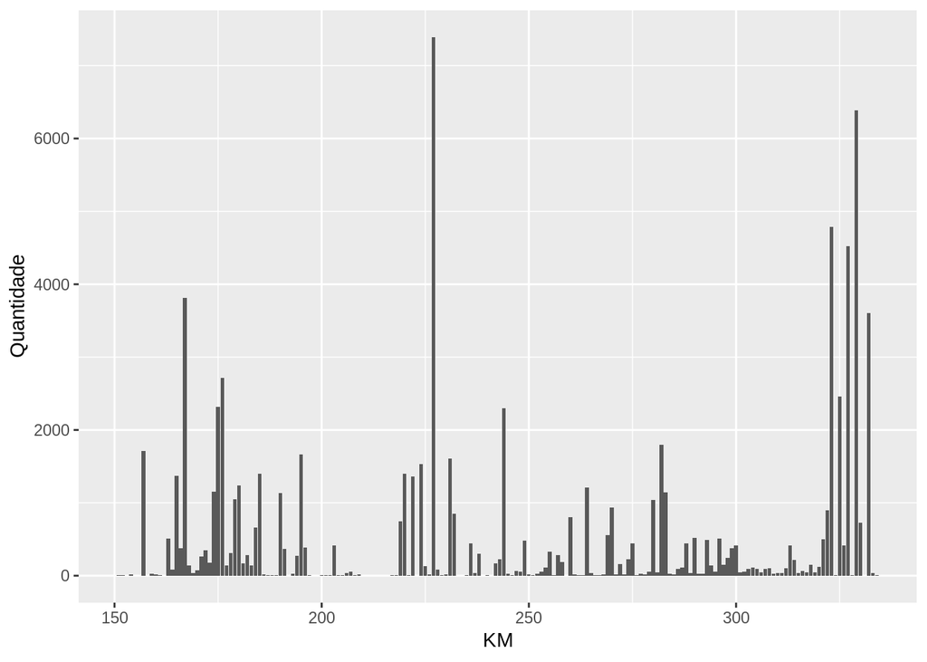

```r
kms_rj %>%
  group_by(uf_infracao, num_km_infracao)%>%
  summarise(registros=n()) %>%
    ggplot(mapping = aes(x = num_km_infracao, y = registros))+
    geom_col()+
      ylab("Quantidade")+
      xlab("KM")
```

#### Infrações mais frequentes entre os trechos com mais infrações - RJ

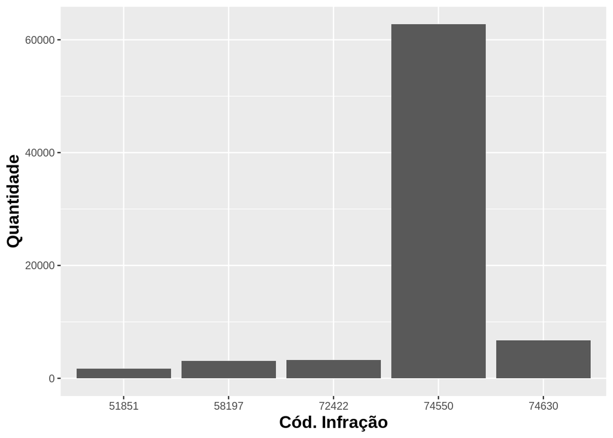

```r
infracoes_mais_comuns_RJ <- group_by(kms_rj, cod_infracao)%>%
  summarise(registros=n()) %>%
  arrange(-registros) %>%
  head(n = 5)

infracoes_mais_comuns_RJ %>%
    ggplot(mapping = aes(x = cod_infracao, y = registros))+
      geom_bar(stat = "identity")+
      ylab("Quantidade")+
      xlab("Cód. Infração")+
      theme(plot.title = element_text(color="red", size=12, face="bold.italic"),
           axis.title=element_text(size=14,face="bold"))
```

```r
tbl_infracao$des_infracao[tbl_infracao$cod_infracao %in% c(51851, 58197)]
```

```
## [1] "Deixar o condutor de usar o cinto de segurança                                                                                                                                                                                                                                                      …
## [2] "Transitar com o veículo em acostamento                                                                                                                                                                                                                                                              …
```

##### Distribuição das Infrações entre os trechos com mais infrações do RJ

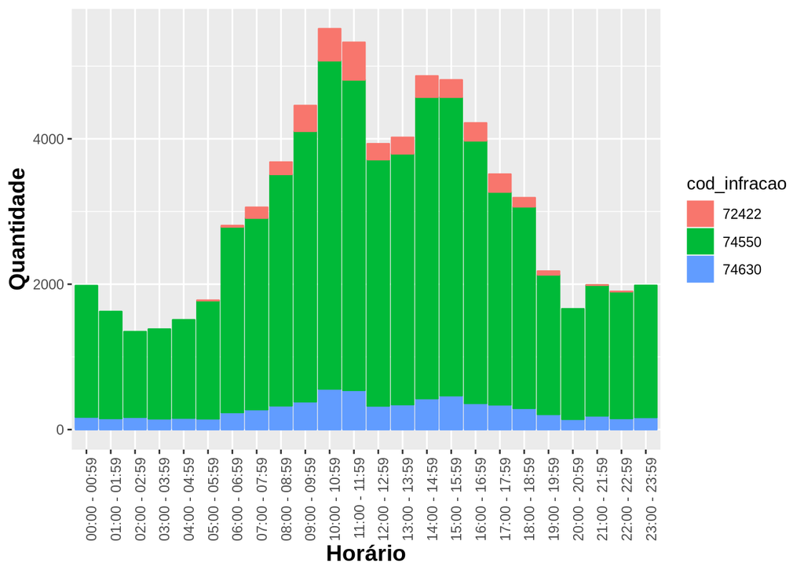

```r
kms_rj %>%
  filter(cod_infracao %in% c(74550, 74630, 72422)) %>%
  group_by(horario, cod_infracao) %>%
    summarise(registros=n()) %>%
    ggplot(mapping = aes(x = horario, y = registros, color=cod_infracao, fill=cod_infracao))+
    geom_bar(stat = "identity")+
      ylab("Quantidade")+
      xlab("Horário")+
      theme(plot.title = element_text(color="red", size=12, face="bold.italic"),
           axis.text.x = element_text(angle = 90, hjust = 1),
           axis.title=element_text(size=14,face="bold"))
```

Novamente o mesmo padrão da distribuição bimodal dos dados.

## Reflexão

Podemos notar que temos o mesmo padrão de distribuição dos dados, as 3 infrações que mais se repetem pelo país são uma constante em quase todos os cenários analisados, creio que uma busca mais a fundo e detalhada nos levaria a encontrar casos atípicos como trechos onde não temos tanto fluxo de veículos. Mas se os problemas estão onde temos um fluxo maior de veículos creio que olhar para demais trechos não nos ajudaria a esclarecer os padrões encontrados em demais trechos sem um olhar de alguém com conhecimento de domínio. Uma das ideias iniciais do projeto era cruzar estes dados com os dados de acidentes, assim podendo ter um olhar mais amplo e ao mesmo tempo mais detalhado da situação do trânsito brasileiro. Creio que perguntas mais pontuais, como: quais horários e períodos da semana costuma-se detectar mais infrações do tipo evasão de barreira poderiam encontrar um padrão diferenciado por localidade.